# 170130_wk2

cd to working dir and load data into the df “INXdf”

```r
setwd('/home/dan/Documents/R_Club/170130_week2/')
INXdf <- read.csv('R-ClubINXdata.csv')
```

1. How many rows and columns are present in the data?

```r
dim(INXdf)
```

```
## [1] 86  7
```

2. What are the column names for the data (I.e. What data are in this spreadsheet)?

```r
colnames(INXdf)
```

```
## [1] "AdrianeCode" "SchulzCode"  "CellID"      "CellType"    "INX1"
## [6] "INX2"        "INX3"
```

3. What do the data look like? Which columns are integers and which are strings?

```r
str(INXdf)
```

```
## 'data.frame':    86 obs. of  7 variables:
##  $ AdrianeCode: Factor w/ 46 levels "869_038 DG","869_038 LG",..: 6 18 27 35 9 14 23 36 2 19 ...
##  $ SchulzCode : Factor w/ 86 levels "#01","#02","#03",..: 20 6 8 10 12 14 16 17 18 19 ...
##  $ CellID     : Factor w/ 13 levels "AGR","DG","IC",..: 9 11 11 11 3 3 12 12 9 3 ...
##  $ CellType   : Factor w/ 2 levels "CG","STG": 2 2 2 2 2 2 2 2 2 2 ...
##  $ INX1       : int  37155 2664 1981 1544 24366 4425 55180 15551 14740 6726 ...
##  $ INX2       : int  13163 1096 714 480 9014 2066 23294 7126 5689 2806 ...
##  $ INX3       : int  9031 652 735 433 6937 1171 18436 3998 4059 2286 ...
```

4. The data are mixed in terms of their cell types and cell identities. Can you sort the data sheet by Cell Type and Cell ID? Print (to the screen) the entire data set after sorting it.

```r
arrange(INXdf, CellType, CellID) %>% head()
```

```
##   AdrianeCode SchulzCode CellID CellType  INX1  INX2 INX3
## 1    Animal 0        #01   LC01       CG 10364  7763 6416
## 2    Animal 1        #11   LC01       CG 11324  7325 4678
## 3    Animal 2        #21   LC01       CG  4274  2867 2592
## 4    Animal 3        #31   LC01       CG  6843  6026 4370
## 5    Animal 4        #41   LC01       CG 14142 11268 7212
## 6    Animal 5        #51   LC01       CG 13798  9349 5822
```

5. Plot a scatterplot of INX1 vs. INX2 for all the data combined (this is Plot 1).

```r
head(INXdf)
```

```
##   AdrianeCode SchulzCode CellID CellType  INX1  INX2 INX3
## 1  869_040 LG      #1 LG     LG      STG 37155 13163 9031
## 2  869_042 MG     #10 MG     MG      STG  2664  1096  652
## 3  869_045 MG     #11 MG     MG      STG  1981   714  735
## 4  869_046 MG     #12 MG     MG      STG  1544   480  433
## 5  869_041 IC     #13 IC     IC      STG 24366  9014 6937
## 6  869_042 IC     #14 IC     IC      STG  4425  2066 1171
```

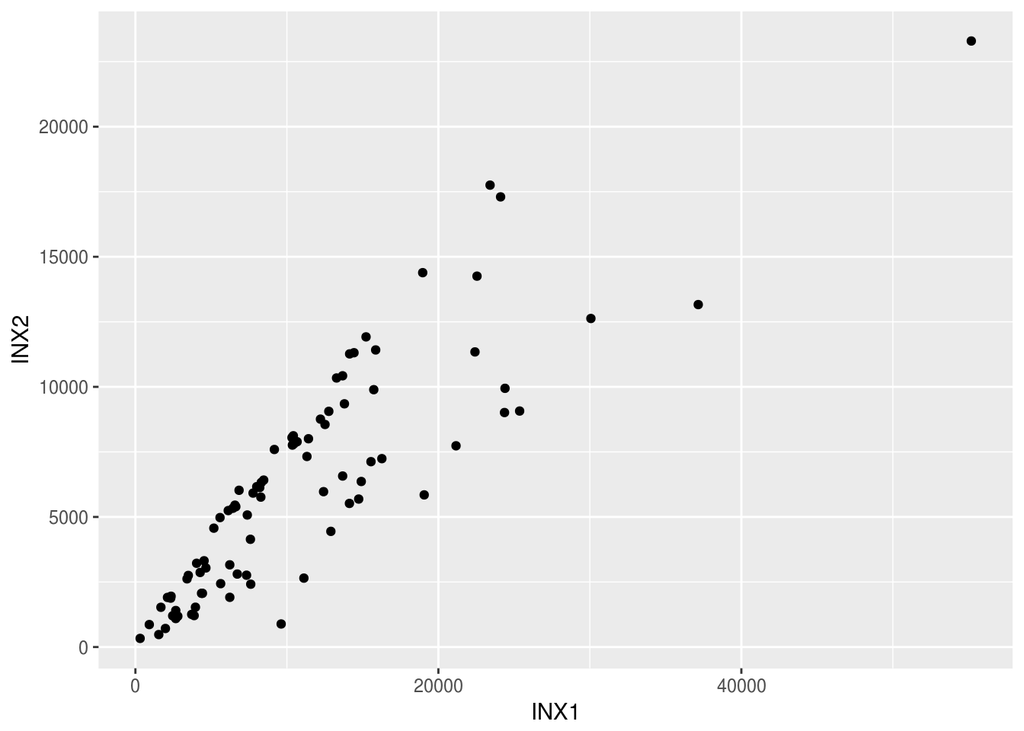

```r
ggplot(INXdf, aes(x=INX1, y=INX2,)) +
  geom_point()
```

6. Plot a scatterplot of INX1 vs. INX2 for all the data combined, but separate the Cell Types (STG vs CG) with different colors (this is Plot 2).

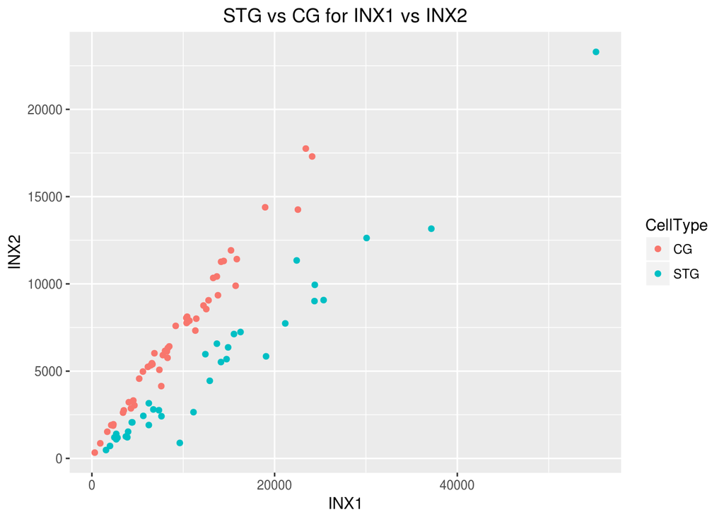

```r
ggplot(INXdf, aes(x=INX1, y=INX2, color=CellType)) +
  geom_point() +
  ggtitle("STG vs CG for INX1 vs INX2") +
  theme(plot.title = element_text(hjust = 0.5))
```

```r
#can also use > labs(title = "test")
#there must be an easier way than using > theme(plot.title = element_text(hjust = 0.5))
```

7. Add regression lines to the scatterplots by Cell Type (this is Plot 3).

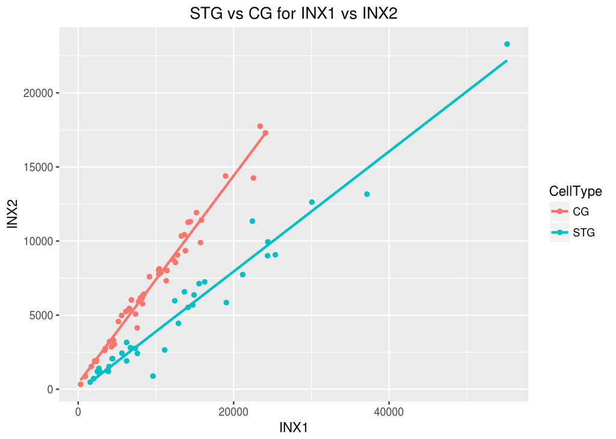

```r
ggplot(INXdf, aes(x=INX1, y=INX2, color=CellType)) +
  geom_point() +
  geom_smooth(method= "lm", se = FALSE) +
  ggtitle("STG vs CG for INX1 vs INX2") +
  theme(plot.title = element_text(hjust = 0.5))
```

8. Plot the same scatterplot, with the regression lines, but identify Cell Type (CellType) by the SHAPE of the points, and identify Cell Identity (CellID) with different colors. (this is Plot 4)

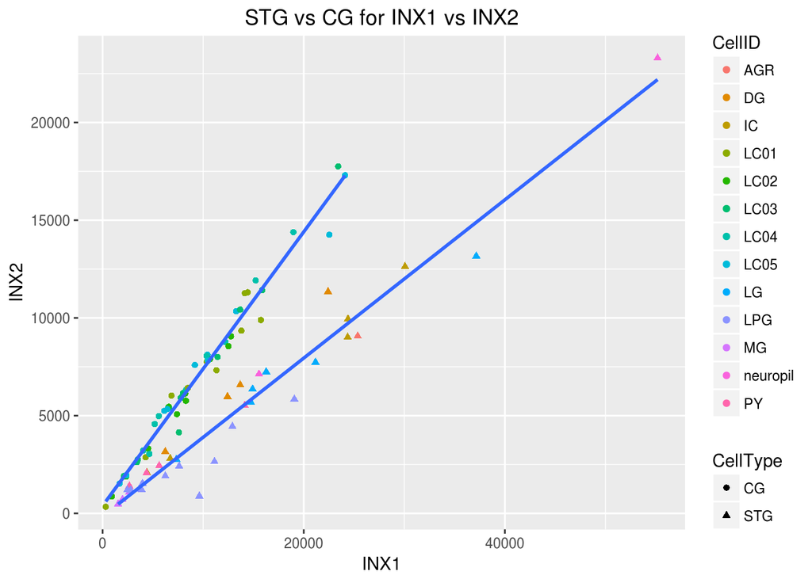

```r
ggplot(INXdf, aes(x=INX1, y=INX2, shape=CellType)) +
  geom_point(aes(color=CellID)) +
  geom_smooth(method= "lm", se = FALSE) +
  ggtitle("STG vs CG for INX1 vs INX2") +
  theme(plot.title = element_text(hjust = 0.5))
```

9. Plot of Boxplot (box and whiskers) for INX3 separated by Cell Type (STG vs CG). Color the boxes by Cell Type, and try to match the formatting of the outliers and points in my plot if you like (Plot 5).

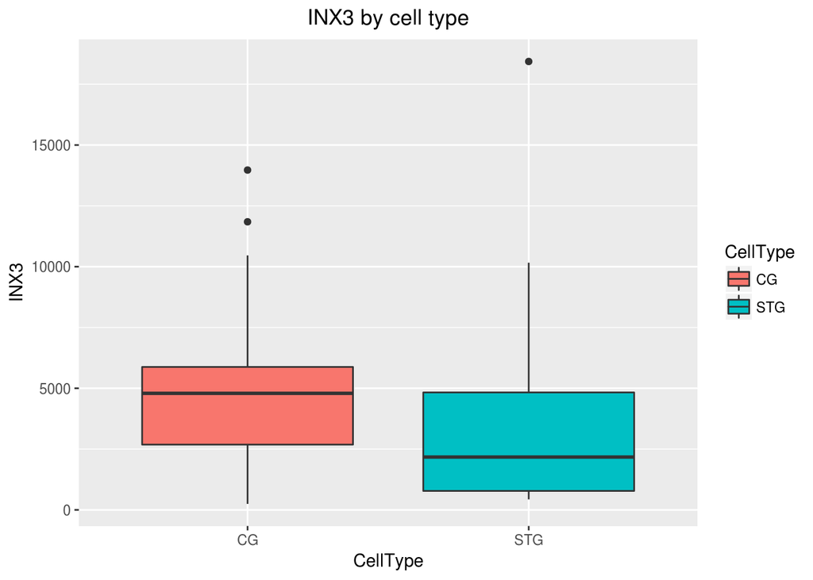

```r
ggplot(INXdf, aes(x=CellType, y=INX3, fill=CellType)) +
  geom_boxplot() +
  ggtitle("INX3 by cell type") +
  theme(plot.title = element_text(hjust = 0.5))
```

10. Plot Boxpots of INX2 and separate Cell Type on the X-xis, and separate by Cell ID in different colors (this is Plot 6).

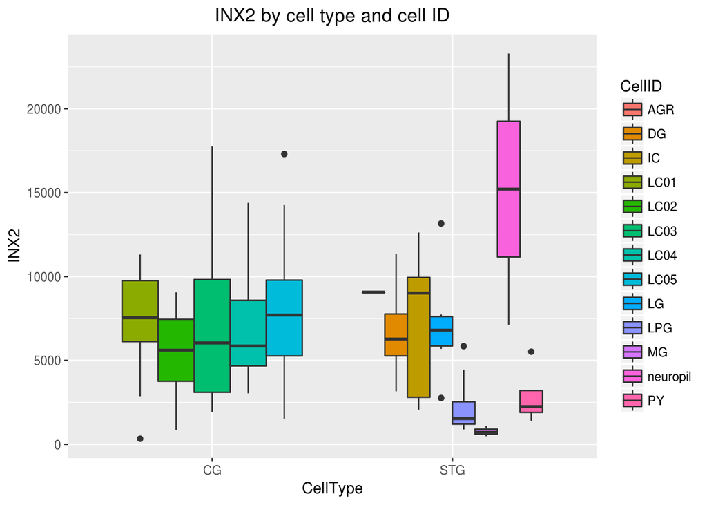

```r
ggplot(INXdf, aes(x=CellType, y=INX2,)) +
  geom_boxplot(aes(fill=CellID)) +
  ggtitle("INX2 by cell type and cell ID") +
  theme(plot.title = element_text(hjust = 0.5))
```